# Salary Growth: City vs City Council (FY 2025)

#### Attrition

Salary growth patterns are closely linked to retention. In FY 2025, Council BU attrition was 28.0% vs Citywide 18.4% (gap: 9.6 pp). Averaged across available years, Council attrition is 24.5% vs Citywide 21.2% (avg gap: 3.4 pp).

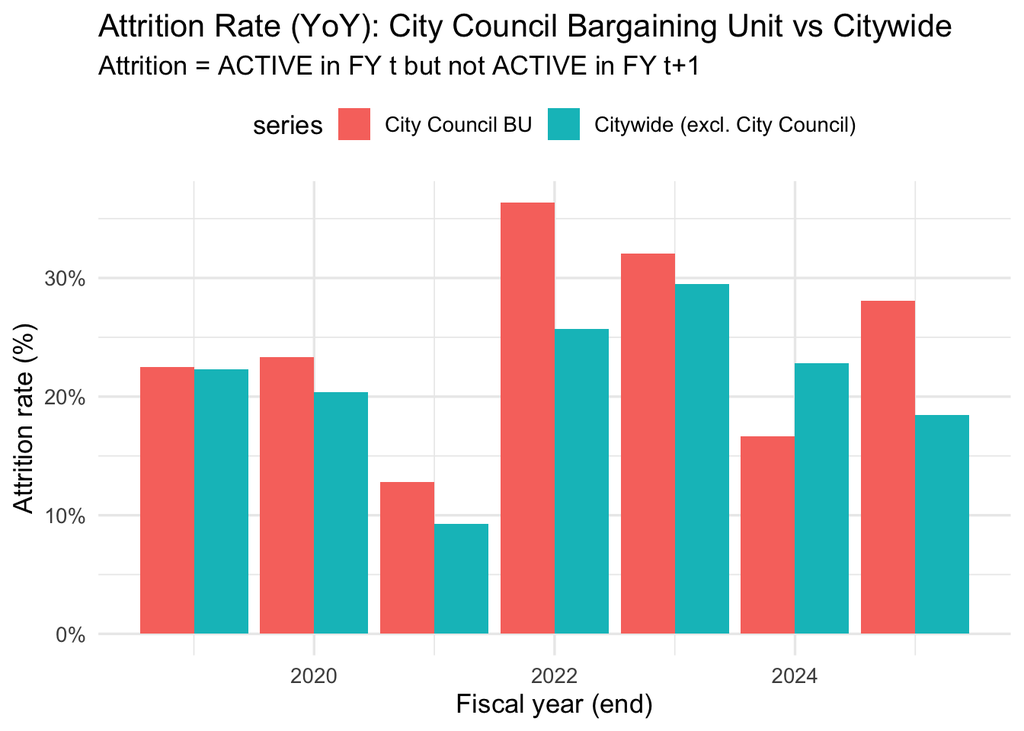

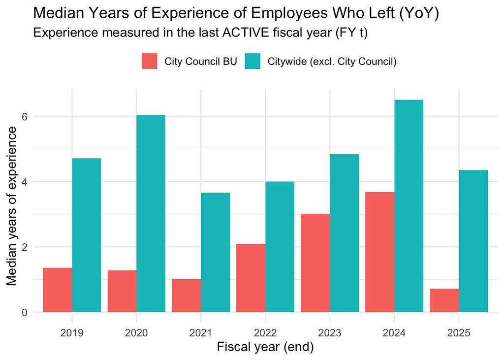

#### Methods

- Data: NYC payroll records
- Sample: Active employees only for FY 2025 comparisons in bargaining unit and comparable titles
- Salary measure: Base salary (log-transformed for modeling)
- Tenure: Years since agency start date, capped at 10 years
- Model: Log-linear regression with controls for sys, grp, and level

| council_title | grp | level | city_titles |
| --- | --- | --- | --- |
| LEGISLATIVE COUNSEL | counsel | junior | *ATTORNEY AT LAW (asg 02); AGENCY ATTORNEY (asg 01); AGENCY ATTORNEY (asg 02) |
| LEGISLATIVE COUNSEL | counsel | senior | AGENCY ATTORNEY (asg 03); AGENCY ATTORNEY (asg 04) |
| LEGISLATIVE PROGRAMMER/ANALYST | data | junior | CITY RESEARCH SCIENTIST (asg 02) |
| LEGISLATIVE PROGRAMMER/ANALYST | data | senior | CITY RESEARCH SCIENTIST (asg 03); CITY RESEARCH SCIENTIST (asg 4A) |
| LEGISLATIVE POLICY ANALYST | policy | junior | STAFF ANALYST (asg 02) |
| SENIOR LEGISLATIVE POLICY ANALYST | policy | senior | ADMINISTRATIVE STAFF ANALYST (asg 00); ASSOCIATE STAFF ANALYST (asg 00) |
| LEGISLATIVE PROGRAMMER/ANALYST | web | junior | COMPUTER SPECIALIST (asg 01); COMPUTER SPECIALIST (asg 02) |
| LEGISLATIVE PROGRAMMER/ANALYST | web | senior | COMPUTER SPECIALIST (asg 03); COMPUTER SPECIALIST (asg 04) |